# Índice de capacidad del proceso

Para llevar a cabo el control de calidad y avanzar en la mejora, primero es necesario conocer la realidad del proceso de fabricación de los productos, entre otros. La capacidad del proceso se refiere a la habilidad del proceso para garantizar que la calidad del producto cumpla con los valores especificados. Como indicador para comprender esta capacidad del proceso, se utiliza el índice de capacidad del proceso.

- Explicación del significado del índice de capacidad del proceso.
- Cálculo del indice del proceso.
- Explicación de los métodos de evaluación del indice de capacidad del proceso.

[Audio_1](https://drive.google.com/file/d/1sVdQu0EUOAH87EOndxZWisuThcw54Rhf/view?usp=drive_link)

```python
import os

try:
  os.chdir('../Python/QCKentei3')
except:
  pass

path = os.getcwd()
```

```python
import numpy as np
import matplotlib.pyplot as plt
import pandas as pd
```

## 06-01 Índice de capacidad del proceso

工程能力指数

### 1. ¿Cuál es el índice de capacidad del proceso?

工程能力指数とは

- Cp: Capability Index (Process Capability Index)
- Cpk: Capability Index (Process Capability Index with Centering)

El **índice de capacidad del proceso**（工程能力指数） es un indicador (**Índice**) que mide la **capacidad de calidad** de un **proceso**.

**Capacidad de calidad**: 質的能力 Lo importante en un proceso es producir muchos artículos conformes y reducir la tasa de no conformidades.

El **índice de capacidad del proceso** es una herramienta excelente que permite conocer la tasa aproximada de no conformidades con solo observar su valor.

Se considera que los datos de medición siguen una **distribución normal**. Por lo tanto, se comparan los valores de las especificaciones con la media y la desviación estándar obtenidas de los datos. Este es el índice de capacidad del proceso. Conociendo este valor, se puede estimar aproximadamente la proporción de artículos **fuera de especificación (la proporción de no conformidades)**.

### 2. Método de cálculo de índice de capacidad del proceso

工程能力指数の計算方法

- $ S_U $: Límite de especificación superior
- $ S_L $: Límite de especificación inferior
- $ C_p $ Índice de capacidad del proceso

#### (1) Cuando el centro de la especificación y el valor promedio coinciden

規格の中央と平均値が一致している場合

- Cuando existen tanto un límite superior como un límite inferior de especificación
  - $ C_p = \frac{1}{6_s} (S_U - S_L) $
- Cuando solo existe un límite superior de especificación
  - $ C_p = \frac{1}{3_s} (S_U -\bar{x}) $
- Cuando solo existen un límite inferior de especificación
  - $ C_p = \frac{1}{3_s} (\bar{x} - S_L) $

#### (2) Cuando existen límites de especificación superior e inferior y el promedio está desviado del centro

上限規格、下限規格があり、平均が中心からずれているとき

- Elegir el valor menor
  - $ C_{pk} = \bigl( \frac{\bar{x} - S_L}{3s} , \frac{S_U - \bar{x} }{3s}\bigr) $

[Audio_2](https://drive.google.com/file/d/1xRFJH8QyIvVniyocPv9SqIvqKWkANOgg/view?usp=drive_link)

## 6.1

次の①～④について、工程能力を計算せよ。

① 上限規格 $ S_U = 61.5 $ cm、 下限規格 $ S_L = 58.5 $ cm、 標準偏差 $ s = 0.4 $ cm、 平均 $ \bar{x} = 60.6 $ cm

② 上限規格 $ S_U = 61.5 $ cm、 標準偏差 $ s = 0.4 $ cm、 平均 $ \bar{x} = 60.6 $ cm

③ 下限規格 $ S_L = 58.5 $ cm、 標準偏差 $ s = 0.4 $ cm、 平均 $ \bar{x} = 60.6 $ cm

④ 平均値が規格の中央からずれていると考えられるとき

上限規格 $ S_U = 61.5 $ cm、 下限規格 $ S_L = 58.5 $ cm、 標準偏差 $ s = 0.4 $ cm、 平均 $ \bar{x} = 60.6 $ cm

Calcule la capacidad del proceso para los siguientes casos ①～④

① Cuando el límite superior de especificación: $ S_U = 61.5 $ cm, el límite inferior de especificación: $ S_L = 58.5 $ cm, la desviación estándar: $ s = 0.4 $ cm, y promedio: $ \bar{x} = 60.6 $ cm

② Cuando el límite superior de especificación: $ S_U = 61.5 $ cm, la desviación estándar: $ s = 0.4 $ cm, y promedio: $ \bar{x} = 60.6 $ cm

③ Cuando el límite inferior de especificación: $ S_L = 58.5 $ cm, la desviación estándar: $ s = 0.4 $ cm, y promedio: $ \bar{x} = 60.6 $ cm

④ Cuando se consider que el valor promedio está desviado del centro de la especificación

el límite superior de especificación: $ S_U = 61.5 $ cm, el límite inferior de especificación: $ S_L = 58.5 $ cm, la desviación estándar: $ s = 0.4 $ cm, y promedio: $ \bar{x} = 60.6 $ cm

```python
def calculate_cpk_and_cp(usl=None, lsl=None, mean=60.6, std_dev=0.4):
    """
    usl: (Upper Specification Limit)
    lsl: (Lower Specification Limit)
    mean: (Sample Mean)
    std_dev: (Standard Deviation)
    """
    if usl is not None and lsl is not None:
        cp = (usl - lsl) / (6 * std_dev)  # Cpの計算
        cpu = (usl - mean) / (3 * std_dev)
        cpl = (mean - lsl) / (3 * std_dev)
        cpk = min(cpu, cpl)
    elif usl is not None:
        cp = (usl - mean) / (3 * std_dev)  # 上限規格のみの場合のCp
        cpk = (usl - mean) / (3 * std_dev)
    elif lsl is not None:
        cp = (mean - lsl) / (3 * std_dev)  # 下限規格のみの場合のCp
        cpk = (mean - lsl) / (3 * std_dev)
    else:
        raise ValueError("Debe especificar al menos unos de los límites superior o inferior de especificación")

    return cp, cpk

# 問題の計算
cases = [
    {"usl": 61.5, "lsl": 58.5, "mean": 60.6, "std_dev": 0.4},  # ①
    {"usl": 61.5, "lsl": None, "mean": 60.6, "std_dev": 0.4}, # ②
    {"usl": None, "lsl": 58.5, "mean": 60.6, "std_dev": 0.4}, # ③
    {"usl": 61.5, "lsl": 58.5, "mean": 60.6, "std_dev": 0.4}  # ④
]

for i, case in enumerate(cases, 1):
    cp, cpk = calculate_cpk_and_cp(**case)
    print(f"Caso {i}: Cp = {cp:.4f}, Cpk = {cpk:.4f}")
```

```
Caso 1: Cp = 1.2500, Cpk = 0.7500
Caso 2: Cp = 0.7500, Cpk = 0.7500
Caso 3: Cp = 1.7500, Cpk = 1.7500
Caso 4: Cp = 1.2500, Cpk = 0.7500
```

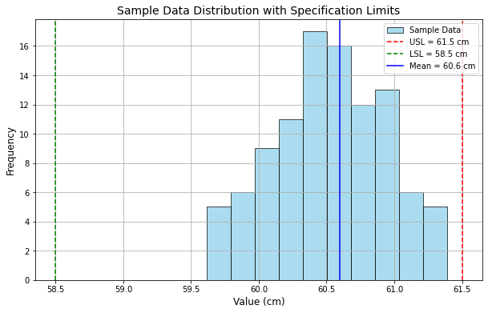

```python
import numpy as np
import matplotlib.pyplot as plt

#
usl = 61.5  # USL
lsl = 58.5  # LSL
mean = 60.6  # Mean
std_dev = 0.4  # Std dev
sample_size = 100  #

#
samples = np.random.normal(loc=mean, scale=std_dev, size=sample_size)

#
plt.figure(figsize=(10, 6))

#
plt.hist(samples, bins=10, color='skyblue', edgecolor='black', alpha=0.7, label='Sample Data')

# USL, LSL
plt.axvline(x=usl, color='r', linestyle='--', label=f'USL = {usl} cm')
plt.axvline(x=lsl, color='g', linestyle='--', label=f'LSL = {lsl} cm')

#
plt.axvline(x=mean, color='b', linestyle='-', label=f'Mean = {mean} cm')

plt.title("Sample Data Distribution with Specification Limits", fontsize=14)
plt.xlabel("Value (cm)", fontsize=12)
plt.ylabel("Frequency", fontsize=12)

plt.legend()
plt.grid(True)
plt.show()
```

### 3. Determinación del índice de capacidad del proceso

工程能力指数の判定

El índice de capacidad del proceso se calcula para determinar la probabilidad de estar fuera de especificación asumiendo que la media y la desviación estándar son los valores reales. En este caso, si se realiza una estandarización, como se puede observar en la **regla de $ \pm 3 \sigma $** en los **gráficos de control**, la probabilidad de exceder estos límites es de aproximadamente **0.3%**, lo cual es **muy raro**.

### Interpretación de índice de Capacidad del Proceso

工程能力指数の解釈と処置

$ 1.67 \leq C_p $ : La capacidad del proceso es más que suficiente

$ 1.33 \geq C_p \geq 1.67 $ : La capacidad del proceso es suficiente

$ 1.00 \geq C_p \geq 1.33 $ : La capacidad del proceso es razonablemente suficiente

$ 0.67 \geq C_p \geq 1.00 $ : La capacidad del proceso es insuficiente

[Audio_3](https://drive.google.com/file/d/15VtAELnkgcAm1C1W1Tn-lf6TWBWSx3A4/view?usp=drive_link)

## 6.2

例題６．１で求めた工程能力指数を判定せよ。

Determine el índice de capacidad del proceso calculado en el Ejemplo 6.1

① $ C_p = 1.25 $ => La capacidad del proceso es razonablemente suficiente

- Sin embargo, dado que la mediana de las especificaciones y la media están desplazadas, es mejor usar el Cpk de la opción ④ para la evaluación.

② $ C_p = 0.75 $ => La capacidad del proceso es insuficiente

③ $ C_p = 1.75 $ => La capacidad del proceso es más que suficiente

④ $ C_{pk} = 0.75 $ => La capacidad del proceso es insuficiente

## Por favor, responda a las preguntas del examen de práctica a través del siguiente enlace.

[Simulacro de examen](https://forms.gle/F7AjJSkUbmiYGq6s9)

```python
notebook_name = 'QCKentei3-6.ipynb'
notebook_name_html = notebook_name.replace(".ipynb",".html")

!jupyter nbconvert --to html {notebook_name}
```

```
[NbConvertApp] Converting notebook QCKentei3-6.ipynb to html
[NbConvertApp] Writing 627788 bytes to QCKentei3-6.html
```